# Modeling three datasets

Author

Oscar Hernandez Mata

**Video game data here: https://think.cs.vt.edu/corgis/csv/video_games/.**

```r
library(tidyverse)
library(dplyr)
library(haven)
library(haven)
library(ggplot2)
library(fastDummies)
library(data.table)
library(equatiomatic)
library(lindia)
library(car)
library(sjPlot)
library(nnet)
library(lmtest)
library(AER)
library(mlogit)
library(MASS)
library(brant)
library(boot)
library(tictoc)
library(caret)
library(ordinal)
video_games <- read_csv("video_games.csv")
```

Note: The count function is giving error. I removed the dplyr package and re installed it and it’s still not working unless I use data$ plus the variable. However, if I use this code it will not render in the end.

**I constructed a variable, called *Solo*, that dichotomizes *Features.Max.Players* into games that are solo play (*Features.Max.Players* = 1) or multiplayer (*Features.Max.Players* > 1).**

```r
data1=video_games%>%dplyr::select(
  `Features.Max Players`,
  Release.Console,
  `Length.Main Story.Median`,
  Metrics.Sales,
  Release.Rating
)%>%
  na.omit()

#count(data1$`Features.Max Players`)

data1$Solo = ifelse(data1$`Features.Max Players` == 1, 1, 0)
#count(data1$Solo)
```

**I constructed a variable, called *Type*, that dichotomizes *Release.Console* into consoles (Nintendo Wii, Xbox 360, and PlayStation 3) vs. handhelds (Nintendo DS and Sony PSP).**

```r
#count(data1$Release.Console)
class(data1$Release.Console)
```

```
[1] "character"
```

```r
data1$Type=ifelse(data1$Release.Console %in% c("Nintendo Wii", "X360", "PlayStation 3"), 1, 0)
#count(data1$Type)
```

**I modeled total sales (*Metrics.Sales*; millions of dollars) as a function of console type (*Type*, as defined above), rating (*Release.Rating*), if the game is multiplayer or solo (*Solo*, as defined above), and the median length of the main storyline (*Length.Main.Story.Median*).**

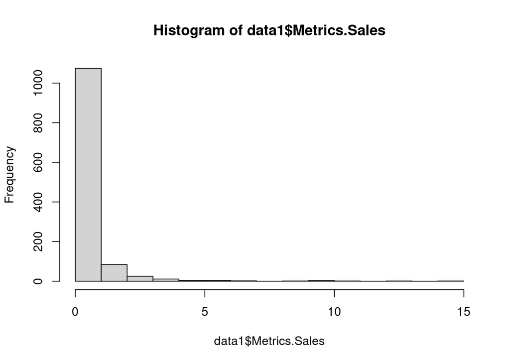

```r
#count(data1$Metrics.Sales)
hist(data1$Metrics.Sales)
```

```r
class(data1$Release.Rating)
```

```
[1] "character"
```

```r
#count(data1$Release.Rating)

#count(data1$`Length.Main Story.Median`)
class(data1$`Length.Main Story.Median`)
```

```
[1] "numeric"
```

```r
data1 <- data1 %>% filter(data1$`Length.Main Story.Median`>0.0000000)

data1$Release.Rating=as.factor(data1$Release.Rating)

m1=lm(data1$Metrics.Sales~Type+Release.Rating+Solo+`Length.Main Story.Median`, data=data1)

almost_sas <- function(aov.results){
  aov_residuals <- residuals(aov.results)
  par(mfrow=c(2,2))
  plot(aov.results, which=1)
  hist(aov_residuals)
  plot(aov.results, which=2)
}
almost_sas(m1)

#count(data1$Metrics.Sales<1)
data1$Metric.Sales_Cat = ifelse(data1$Metrics.Sales < 1, 0, 1)
#count(data1$Metric.Sales_Cat)

m2=glm(Metric.Sales_Cat~Type+Release.Rating+Solo+`Length.Main Story.Median`, data=data1, family = "binomial")
summary(m2)
```

```
Call:
glm(formula = Metric.Sales_Cat ~ Type + Release.Rating + Solo +
    `Length.Main Story.Median`, family = "binomial", data = data1)

Deviance Residuals:
    Min       1Q   Median       3Q      Max
-1.3069  -0.6035  -0.4883  -0.3992   2.5075

Coefficients:
                            Estimate Std. Error z value Pr(>|z|)
(Intercept)                -1.927046   0.293066  -6.575 4.85e-11 ***
Type                        0.576363   0.231570   2.489  0.01281 *
Release.RatingM            -0.708294   0.288287  -2.457  0.01401 *
Release.RatingT            -0.201031   0.210289  -0.956  0.33909
Solo                       -0.490900   0.222117  -2.210  0.02710 *
`Length.Main Story.Median`  0.026444   0.009132   2.896  0.00378 **
---
Signif. codes:  0 '***' 0.001 '**' 0.01 '*' 0.05 '.' 0.1 ' ' 1

(Dispersion parameter for binomial family taken to be 1)

    Null deviance: 748.74  on 905  degrees of freedom
Residual deviance: 717.47  on 900  degrees of freedom
AIC: 729.47

Number of Fisher Scoring iterations: 5
```

[figure not shown]

```r
ec0=round(exp(coefficients(m2)), 4)
c0=coefficients(m2)
```

The residuals revealed the absence of normality in the linear regression model. Therefore, I decided to proceed with a binary logistic regression model. I divided Metric.Sales_Cat in two categories.

**Resulting model.**

```r
extract_eq(m2, use_coefs = TRUE)
```

$$\log\left[ \frac { \widehat{P( \operatorname{Metric.Sales\_Cat} = \operatorname{1} )} }{ 1 - \widehat{P( \operatorname{Metric.Sales\_Cat} = \operatorname{1} )} } \right] = -1.93 + 0.58(\operatorname{Type}) - 0.71(\operatorname{Release.Rating}_{\operatorname{M}}) - 0.2(\operatorname{Release.Rating}_{\operatorname{T}}) - 0.49(\operatorname{Solo}) + 0.03(\operatorname{`Length.Main\ Story.Median`})$$

**Significant predictors of total sales. Test at the** $\alpha=0.05$ level.

```r
fullType=glm(Metric.Sales_Cat~Type+Release.Rating+Solo+data1$`Length.Main Story.Median`, data=data1, family = "binomial")
reducedType=glm(Metric.Sales_Cat~Release.Rating+Solo+data1$`Length.Main Story.Median`, data=data1, family = "binomial")
anova(reducedType, fullType, test = "Chisq")
```

```
Analysis of Deviance Table

Model 1: Metric.Sales_Cat ~ Release.Rating + Solo + data1$`Length.Main Story.Median`
Model 2: Metric.Sales_Cat ~ Type + Release.Rating + Solo + data1$`Length.Main Story.Median`
  Resid. Df Resid. Dev Df Deviance Pr(>Chi)
1       901     723.77
2       900     717.47  1   6.2981  0.01209 *
---
Signif. codes:  0 '***' 0.001 '**' 0.01 '*' 0.05 '.' 0.1 ' ' 1
```

```r
fullRating=glm(Metric.Sales_Cat~Type+Release.Rating+Solo+data1$`Length.Main Story.Median`, data=data1, family = "binomial")
reducedRating=glm(Metric.Sales_Cat~Type+Solo+data1$`Length.Main Story.Median`, data=data1, family = "binomial")
anova(reducedRating, fullRating, test = "Chisq")
```

```
Analysis of Deviance Table

Model 1: Metric.Sales_Cat ~ Type + Solo + data1$`Length.Main Story.Median`
Model 2: Metric.Sales_Cat ~ Type + Release.Rating + Solo + data1$`Length.Main Story.Median`
  Resid. Df Resid. Dev Df Deviance Pr(>Chi)
1       902     724.06
2       900     717.47  2   6.5859  0.03714 *
---
Signif. codes:  0 '***' 0.001 '**' 0.01 '*' 0.05 '.' 0.1 ' ' 1
```

```r
fullSolo=glm(Metric.Sales_Cat~Type+Release.Rating+Solo+data1$`Length.Main Story.Median`, data=data1, family = "binomial")
reducedSolo=glm(Metric.Sales_Cat~Type+Release.Rating+data1$`Length.Main Story.Median`, data=data1, family = "binomial")
anova(reducedSolo, fullSolo, test = "Chisq")
```

```
Analysis of Deviance Table

Model 1: Metric.Sales_Cat ~ Type + Release.Rating + data1$`Length.Main Story.Median`
Model 2: Metric.Sales_Cat ~ Type + Release.Rating + Solo + data1$`Length.Main Story.Median`
  Resid. Df Resid. Dev Df Deviance Pr(>Chi)
1       901     722.36
2       900     717.47  1   4.8899  0.02701 *
---
Signif. codes:  0 '***' 0.001 '**' 0.01 '*' 0.05 '.' 0.1 ' ' 1
```

```r
fullMedian=glm(Metric.Sales_Cat~Type+Release.Rating+Solo+data1$`Length.Main Story.Median`, data=data1, family = "binomial")
reducedMedian=glm(Metric.Sales_Cat~Type+Release.Rating+Solo, data=data1, family = "binomial")
anova(reducedMedian, fullMedian, test = "Chisq")
```

```
Analysis of Deviance Table

Model 1: Metric.Sales_Cat ~ Type + Release.Rating + Solo
Model 2: Metric.Sales_Cat ~ Type + Release.Rating + Solo + data1$`Length.Main Story.Median`
  Resid. Df Resid. Dev Df Deviance Pr(>Chi)
1       901     725.21
2       900     717.47  1   7.7353 0.005415 **
---
Signif. codes:  0 '***' 0.001 '**' 0.01 '*' 0.05 '.' 0.1 ' ' 1
```

Our results show that Type is a significant predictor of Metric.Sales_Cat. We calculated p-value=0.01209, which is less than alpha=0.05. Our results reveal that Release Rating is a significant predictor of Metric.Sales.We calculated p-value=0.03714, which is less than alpha=0.05. Our results reveal that Solo is a significant predictor of Metric.Sales.We calculated p-value=0.02701, which is less than alpha=0.05. Our results show that Length.Main Story.Median is a significant predictor of Metric.Sales.We calculated p-value=0.005415, which is less than alpha=0.05.

**I modeled total sales (*Metrics.Sales*; millions of dollars) as a function of console (*Release.Console*), rating (*Release.Rating*), number of players (*Features.Max.Players*), and the median length of the main storyline (*Length.Main.Story.Median*).**

```r
#count(data1$`Features.Max Players`)

class(data1$Release.Console)
```

```
[1] "character"
```

```r
#count(data1$Release.Console)
data1$Release_Console_Numbered <- ifelse(data1$Release.Console == "Nintendo DS", 1,
                                     ifelse(data1$Release.Console == "Nintendo Wii", 2,
                                            ifelse(data1$Release.Console == "PlayStation 3", 3,
                                                   ifelse(data1$Release.Console == "Sony PSP", 4, 5))))
#count(data1$Release_Console_Numbered)

m3=glm(Metric.Sales_Cat~Release_Console_Numbered+Release.Rating+`Features.Max Players`+`Length.Main Story.Median`, data=data1, family = "binomial")
summary(m3)
```

```
Call:
glm(formula = Metric.Sales_Cat ~ Release_Console_Numbered + Release.Rating +
    `Features.Max Players` + `Length.Main Story.Median`, family = "binomial",
    data = data1)

Deviance Residuals:
    Min       1Q   Median       3Q      Max
-1.0838  -0.5719  -0.5087  -0.4310   2.3516

Coefficients:
                            Estimate Std. Error z value Pr(>|z|)
(Intercept)                -2.334745   0.288383  -8.096 5.68e-16 ***
Release_Console_Numbered    0.001071   0.063490   0.017 0.986538
Release.RatingM            -0.660525   0.286786  -2.303 0.021267 *
Release.RatingT            -0.214859   0.209604  -1.025 0.305330
`Features.Max Players`      0.269082   0.076847   3.502 0.000463 ***
`Length.Main Story.Median`  0.025057   0.008943   2.802 0.005081 **
---
Signif. codes:  0 '***' 0.001 '**' 0.01 '*' 0.05 '.' 0.1 ' ' 1

(Dispersion parameter for binomial family taken to be 1)

    Null deviance: 748.74  on 905  degrees of freedom
Residual deviance: 726.33  on 900  degrees of freedom
AIC: 738.33

Number of Fisher Scoring iterations: 4
```

```r
c1=coefficients(m3)

ec1=round(exp(coefficients(m3)), 4)
```

**Resulting model.**

```r
extract_eq(m3, use_coefs = TRUE)
```

$$\log\left[ \frac { \widehat{P( \operatorname{Metric.Sales\_Cat} = \operatorname{1} )} }{ 1 - \widehat{P( \operatorname{Metric.Sales\_Cat} = \operatorname{1} )} } \right] = -2.33 + 0(\operatorname{Release\_Console\_Numbered}) - 0.66(\operatorname{Release.Rating}_{\operatorname{M}}) - 0.21(\operatorname{Release.Rating}_{\operatorname{T}}) + 0.27(\operatorname{`Features.Max\ Players`}) + 0.03(\operatorname{`Length.Main\ Story.Median`})$$

**Significant predictors of total sales. Test at the** $\alpha=0.05$ level.

```r
fullRelCons=glm(Metric.Sales_Cat~Release_Console_Numbered+Release.Rating+data1$`Features.Max Players`+data1$`Length.Main Story.Median`, data=data1, family = "binomial")
reducedRelCons=glm(Metric.Sales_Cat~Release.Rating+data1$`Features.Max Players`+data1$`Length.Main Story.Median`, data=data1, family = "binomial")
anova(reducedRelCons, fullRelCons,  test = "Chisq")
```

```
Analysis of Deviance Table

Model 1: Metric.Sales_Cat ~ Release.Rating + data1$`Features.Max Players` +
    data1$`Length.Main Story.Median`
Model 2: Metric.Sales_Cat ~ Release_Console_Numbered + Release.Rating +
    data1$`Features.Max Players` + data1$`Length.Main Story.Median`
  Resid. Df Resid. Dev Df   Deviance Pr(>Chi)
1       901     726.33
2       900     726.33  1 0.00028469   0.9865
```

```r
fullReRating=glm(Metric.Sales_Cat~Release_Console_Numbered+Release.Rating+data1$`Features.Max Players`+data1$`Length.Main Story.Median`, data=data1, family = "binomial")
reducedReRating=glm(Metric.Sales_Cat~Release_Console_Numbered+data1$`Features.Max Players`+data1$`Length.Main Story.Median`, data=data1, family = "binomial")
anova(reducedReRating, fullReRating,  test = "Chisq")
```

```
Analysis of Deviance Table

Model 1: Metric.Sales_Cat ~ Release_Console_Numbered + data1$`Features.Max Players` +
    data1$`Length.Main Story.Median`
Model 2: Metric.Sales_Cat ~ Release_Console_Numbered + Release.Rating +
    data1$`Features.Max Players` + data1$`Length.Main Story.Median`
  Resid. Df Resid. Dev Df Deviance Pr(>Chi)
1       902     732.10
2       900     726.33  2    5.772   0.0558 .
---
Signif. codes:  0 '***' 0.001 '**' 0.01 '*' 0.05 '.' 0.1 ' ' 1
```

```r
fullMaxPlayers=glm(Metric.Sales_Cat~Release_Console_Numbered+Release.Rating+data1$`Features.Max Players`+data1$`Length.Main Story.Median`, data=data1, family = "binomial")
reducedMaxPlayers=glm(Metric.Sales_Cat~Release_Console_Numbered+Release.Rating+data1$`Length.Main Story.Median`, data=data1, family = "binomial")
anova(reducedMaxPlayers, fullMaxPlayers,  test = "Chisq")
```

```
Analysis of Deviance Table

Model 1: Metric.Sales_Cat ~ Release_Console_Numbered + Release.Rating +
    data1$`Length.Main Story.Median`
Model 2: Metric.Sales_Cat ~ Release_Console_Numbered + Release.Rating +
    data1$`Features.Max Players` + data1$`Length.Main Story.Median`
  Resid. Df Resid. Dev Df Deviance  Pr(>Chi)
1       901     737.70
2       900     726.33  1   11.369 0.0007468 ***
---
Signif. codes:  0 '***' 0.001 '**' 0.01 '*' 0.05 '.' 0.1 ' ' 1
```

```r
fullMSMedian=glm(Metric.Sales_Cat~Release_Console_Numbered+Release.Rating+data1$`Features.Max Players`+data1$`Length.Main Story.Median`, data=data1, family = "binomial")
reducedMSMedian=glm(Metric.Sales_Cat~Release_Console_Numbered+Release.Rating+data1$`Features.Max Players`, data=data1, family = "binomial")
anova(reducedMSMedian, fullMSMedian,  test = "Chisq")
```

```
Analysis of Deviance Table

Model 1: Metric.Sales_Cat ~ Release_Console_Numbered + Release.Rating +
    data1$`Features.Max Players`
Model 2: Metric.Sales_Cat ~ Release_Console_Numbered + Release.Rating +
    data1$`Features.Max Players` + data1$`Length.Main Story.Median`
  Resid. Df Resid. Dev Df Deviance Pr(>Chi)
1       901     733.52
2       900     726.33  1    7.192 0.007323 **
---
Signif. codes:  0 '***' 0.001 '**' 0.01 '*' 0.05 '.' 0.1 ' ' 1
```

Our results reveal that Release.Console is not a significant predictor of Metric.Sales_Cat. We calculated p-value=0.9865, which is greater than alpha=0.05. Our results reveal that Release.Rating is not a significant predictor of Metric.Sales_Cat.We calculated p-value=0.0558, which is greater than alpha=0.05. Our results reveal that Features.Max Players is a significant predictor of Metric.Sales_Cat.We calculated p-value=0.0007468, which is less than alpha=0.05. Our results reveal that Length.Main Story.Median is a significant predictor of Metric.Sales_Cat.We calculated p-value=0.007323, which is less than alpha=0.05.

**I used leave-one-out cross validation to determine which model fits better.**

```r
set.seed(45)
cv_error <- cv.glm(data1, m2)
cv_error$delta
```

```
[1] 0.1210499 0.1210490
```

```r
set.seed(45)
cv_error <- cv.glm(data1, m3)
cv_error$delta
```

```
[1] 0.1225014 0.1225003
```

The results reveal that model 2 is a better fit. I calculated CV(n)= 0.1210499 0.1210490, which is smaller than m3 CV(n)=0.1225014 0.1225003.

**Summary**

```r
c0
```

```
               (Intercept)                       Type
               -1.92704590                 0.57636299
           Release.RatingM            Release.RatingT
               -0.70829429                -0.20103069
                      Solo `Length.Main Story.Median`
               -0.49089977                 0.02644363
```

```r
ec0
```

```
               (Intercept)                       Type
                    0.1456                     1.7796
           Release.RatingM            Release.RatingT
                    0.4925                     0.8179
                      Solo `Length.Main Story.Median`
                    0.6121                     1.0268
```

Consoles (Nintendo Wii, Xbox 360, and PlayStation 3) have 80% higher odds of reaching 1.0 in millions of dollars in Metric.Sales than handhelds (Nintendo DS and Sony PSP). On the other hand, Release.RatingM has 50% lower odds of reaching 1.0 in millions of dollars in Metric.Sales than Release.RatingE. Besides, Release.RatingT has 20% lower odds of reaching 1.0 in millions of dollars in Metric.Sales than Release.RatingE. Games that allow a Max.Players of 1 have 40% lower odds of reaching 1.0 in millions of dollars in Metric.Sales than games that support greater amount of Max.Players. Finally, for every unit increase in Length.Main Story.Median the odds of Metric.Sales reaching 1.0 in millions of dollars increase by 2%.

```r
c0
```

```
               (Intercept)                       Type
               -1.92704590                 0.57636299
           Release.RatingM            Release.RatingT
               -0.70829429                -0.20103069
                      Solo `Length.Main Story.Median`
               -0.49089977                 0.02644363
```

**I constructed a data visualization for the model that fit better to aid in explaining model results.**

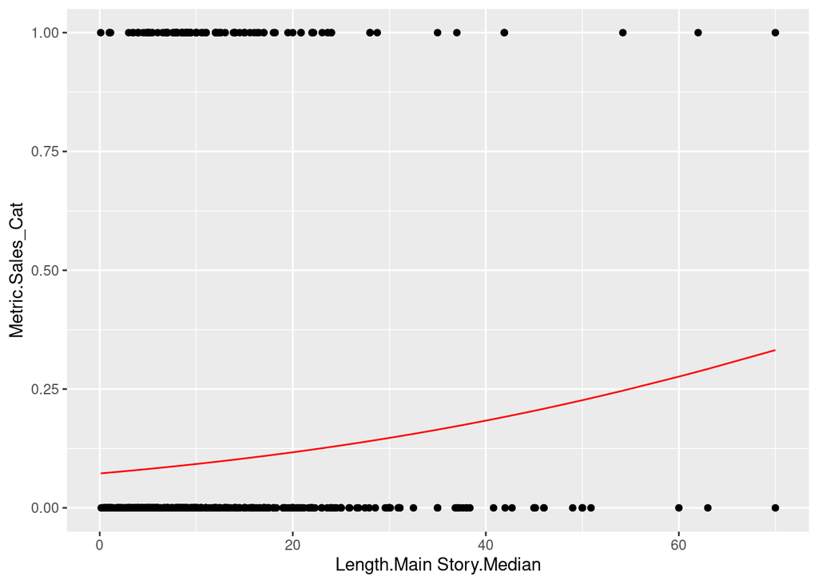

```r
data1=data1%>%mutate(
 pred_lmsm=exp(c0[1]+c0[2]+c0[3]+c0[5]+c0[6]*`Length.Main Story.Median` )/(1+exp(c0[1]+c0[2]+c0[3]+c0[5]+c0[6]*`Length.Main Story.Median` ))
)

data1 %>% ggplot(aes(x =`Length.Main Story.Median` , y =Metric.Sales_Cat )) +
geom_point() +
geom_line(aes(y = pred_lmsm), color="red")
```

The graphic support the interpretation that for every unit increase in the length of main story median the odds of Metric.Sales of reaching 1.0 in millions of dollars increase.

**Hospital safety data here: https://corgis-edu.github.io/corgis/csv/hospitals/.**

```r
hospitals <- read_csv("hospitals.csv")
```

**I am interested in analyzing data from hospitals that are *not* of unknown or proprietary facility type (*Facility.Type*). I performed the appropriate data management steps to create a subset of data meeting this criteria.**

```r
data2=hospitals%>%dplyr::select(
  Facility.Type,
  Rating.Safety,
  `Procedure.Heart Attack.Cost`
)%>%
  na.omit()

#count(data2$Facility.Type)
class(data2$Facility.Type)
```

```
[1] "character"
```

```r
data2 = subset(data2, Facility.Type != "Unknown" & Facility.Type != "Proprietary")
#count(data2$Facility.Type)

class(data2$Facility.Type)
```

```
[1] "character"
```

**First, I modeled the safety ratings (*Rating.Safety*) that are *either* above or below the national average as a function of facility type (I used private as the reference group), cost of heart attack procedure, and the interaction between facility type and cost of heart attack procedure.**

```r
#count(data2$Rating.Safety)
class(data2$Rating.Safety)
```

```
[1] "character"
```

```r
data2 = subset(data2, Rating.Safety != "None" & Rating.Safety != "Same")
#count(data2$Rating.Safety)
data2$Rating.Safety = ifelse(data2$Rating.Safety == "Above", 0, 1)

data2 = dummy_cols(data2, select_columns = c("Facility.Type"))

data2=data2%>%filter(data2$`Procedure.Heart Attack.Cost`>0)
class(data2$`Procedure.Heart Attack.Cost`)
```

```
[1] "numeric"
```

```r
m4=glm(Rating.Safety~Facility.Type_Church+Facility.Type_Government+`Procedure.Heart Attack.Cost`+Facility.Type_Church:`Procedure.Heart Attack.Cost`+Facility.Type_Government:`Procedure.Heart Attack.Cost`, data=data2, family = "binomial")

summary(m4)
```

```
Call:
glm(formula = Rating.Safety ~ Facility.Type_Church + Facility.Type_Government +
    `Procedure.Heart Attack.Cost` + Facility.Type_Church:`Procedure.Heart Attack.Cost` +
    Facility.Type_Government:`Procedure.Heart Attack.Cost`, family = "binomial",
    data = data2)

Deviance Residuals:
   Min      1Q  Median      3Q     Max
-1.436  -1.115  -1.066   1.237   1.472

Coefficients:
                                                         Estimate Std. Error
(Intercept)                                            -1.062e+00  1.046e+00
Facility.Type_Church                                   -2.273e+00  2.366e+00
Facility.Type_Government                               -8.415e-01  2.302e+00
`Procedure.Heart Attack.Cost`                           3.721e-05  4.364e-05
Facility.Type_Church:`Procedure.Heart Attack.Cost`      1.021e-04  9.840e-05
Facility.Type_Government:`Procedure.Heart Attack.Cost`  4.362e-05  9.685e-05
                                                       z value Pr(>|z|)
(Intercept)                                             -1.016    0.310
Facility.Type_Church                                    -0.961    0.337
Facility.Type_Government                                -0.366    0.715
`Procedure.Heart Attack.Cost`                            0.853    0.394
Facility.Type_Church:`Procedure.Heart Attack.Cost`       1.038    0.299
Facility.Type_Government:`Procedure.Heart Attack.Cost`   0.450    0.652

(Dispersion parameter for binomial family taken to be 1)

    Null deviance: 1796.5  on 1298  degrees of freedom
Residual deviance: 1790.0  on 1293  degrees of freedom
AIC: 1802

Number of Fisher Scoring iterations: 3
```

```r
c2=coefficients(m4)
ec2=round(exp(coefficients(m4)), 4)

ec2
```

```
                                           (Intercept)
                                                0.3458
                                  Facility.Type_Church
                                                0.1030
                              Facility.Type_Government
                                                0.4310
                         `Procedure.Heart Attack.Cost`
                                                1.0000
    Facility.Type_Church:`Procedure.Heart Attack.Cost`
                                                1.0001
Facility.Type_Government:`Procedure.Heart Attack.Cost`
                                                1.0000
```

**Resulting model.**

```r
extract_eq(m4, use_coefs = TRUE)
```

$$\log\left[ \frac { \widehat{P( \operatorname{Rating.Safety} = \operatorname{1} )} }{ 1 - \widehat{P( \operatorname{Rating.Safety} = \operatorname{1} )} } \right] = -1.06 - 2.27(\operatorname{Facility.Type\_Church}) - 0.84(\operatorname{Facility.Type\_Government}) + 0(\operatorname{`Procedure.Heart\ Attack.Cost`}) + 0(\operatorname{Facility.Type\_Church} \times \operatorname{`Procedure.Heart\ Attack.Cost`}) + 0(\operatorname{Facility.Type\_Government} \times \operatorname{`Procedure.Heart\ Attack.Cost`})$$

**Significant predictors of safety rating. Test at the** $\alpha=0.05$ level.

```r
fullChurch=glm(Rating.Safety~Facility.Type_Church+Facility.Type_Government+`Procedure.Heart Attack.Cost`+Facility.Type_Church:`Procedure.Heart Attack.Cost`+Facility.Type_Government:`Procedure.Heart Attack.Cost`, data=data2, family = "binomial")

reducedCurch=glm(Rating.Safety~Facility.Type_Government+`Procedure.Heart Attack.Cost`+Facility.Type_Church:`Procedure.Heart Attack.Cost`+Facility.Type_Government:`Procedure.Heart Attack.Cost`, data=data2, family = "binomial")
anova(reducedCurch, fullChurch, test = "Chisq")
```

```
Analysis of Deviance Table

Model 1: Rating.Safety ~ Facility.Type_Government + `Procedure.Heart Attack.Cost` +
    Facility.Type_Church:`Procedure.Heart Attack.Cost` + Facility.Type_Government:`Procedure.Heart Attack.Cost`
Model 2: Rating.Safety ~ Facility.Type_Church + Facility.Type_Government +
    `Procedure.Heart Attack.Cost` + Facility.Type_Church:`Procedure.Heart Attack.Cost` +
    Facility.Type_Government:`Procedure.Heart Attack.Cost`
  Resid. Df Resid. Dev Df Deviance Pr(>Chi)
1      1294     1790.9
2      1293     1790.0  1  0.93181   0.3344
```

```r
fullGovernment=glm(Rating.Safety~Facility.Type_Church+Facility.Type_Government+`Procedure.Heart Attack.Cost`+Facility.Type_Church:`Procedure.Heart Attack.Cost`+Facility.Type_Government:`Procedure.Heart Attack.Cost`, data=data2, family = "binomial")

reducedGovernment=glm(Rating.Safety~Facility.Type_Church+`Procedure.Heart Attack.Cost`+Facility.Type_Church:`Procedure.Heart Attack.Cost`+Facility.Type_Government:`Procedure.Heart Attack.Cost`, data=data2, family = "binomial")
anova(reducedGovernment, fullGovernment, test = "Chisq")
```

```
Analysis of Deviance Table

Model 1: Rating.Safety ~ Facility.Type_Church + `Procedure.Heart Attack.Cost` +
    Facility.Type_Church:`Procedure.Heart Attack.Cost` + Facility.Type_Government:`Procedure.Heart Attack.Cost`
Model 2: Rating.Safety ~ Facility.Type_Church + Facility.Type_Government +
    `Procedure.Heart Attack.Cost` + Facility.Type_Church:`Procedure.Heart Attack.Cost` +
    Facility.Type_Government:`Procedure.Heart Attack.Cost`
  Resid. Df Resid. Dev Df Deviance Pr(>Chi)
1      1294     1790.1
2      1293     1790.0  1  0.13399   0.7143
```

```r
fullPHAC=glm(Rating.Safety~Facility.Type_Church+Facility.Type_Government+`Procedure.Heart Attack.Cost`+Facility.Type_Church:`Procedure.Heart Attack.Cost`+Facility.Type_Government:`Procedure.Heart Attack.Cost`, data=data2, family = "binomial")

reducedPHAC=glm(Rating.Safety~Facility.Type_Church+Facility.Type_Government+Facility.Type_Church:`Procedure.Heart Attack.Cost`+Facility.Type_Government:`Procedure.Heart Attack.Cost`, data=data2, family = "binomial")
anova(reducedPHAC, fullPHAC, test = "Chisq")
```

```
Analysis of Deviance Table

Model 1: Rating.Safety ~ Facility.Type_Church + Facility.Type_Government +
    Facility.Type_Church:`Procedure.Heart Attack.Cost` + Facility.Type_Government:`Procedure.Heart Attack.Cost`
Model 2: Rating.Safety ~ Facility.Type_Church + Facility.Type_Government +
    `Procedure.Heart Attack.Cost` + Facility.Type_Church:`Procedure.Heart Attack.Cost` +
    Facility.Type_Government:`Procedure.Heart Attack.Cost`
  Resid. Df Resid. Dev Df Deviance Pr(>Chi)
1      1294     1790.7
2      1293     1790.0  1  0.72771   0.3936
```

```r
fullChurchPHAC=glm(Rating.Safety~Facility.Type_Church+Facility.Type_Government+`Procedure.Heart Attack.Cost`+Facility.Type_Church:`Procedure.Heart Attack.Cost`+Facility.Type_Government:`Procedure.Heart Attack.Cost`, data=data2, family = "binomial")

reducedChurchPHAC=glm(Rating.Safety~Facility.Type_Church+Facility.Type_Government+`Procedure.Heart Attack.Cost`+Facility.Type_Government:`Procedure.Heart Attack.Cost`, data=data2, family = "binomial")
anova(reducedChurchPHAC, fullChurchPHAC, test = "Chisq")
```

```
Analysis of Deviance Table

Model 1: Rating.Safety ~ Facility.Type_Church + Facility.Type_Government +
    `Procedure.Heart Attack.Cost` + Facility.Type_Government:`Procedure.Heart Attack.Cost`
Model 2: Rating.Safety ~ Facility.Type_Church + Facility.Type_Government +
    `Procedure.Heart Attack.Cost` + Facility.Type_Church:`Procedure.Heart Attack.Cost` +
    Facility.Type_Government:`Procedure.Heart Attack.Cost`
  Resid. Df Resid. Dev Df Deviance Pr(>Chi)
1      1294     1791.1
2      1293     1790.0  1   1.0882   0.2969
```

```r
fullGovernmentPHAC=glm(Rating.Safety~Facility.Type_Church+Facility.Type_Government+`Procedure.Heart Attack.Cost`+Facility.Type_Church:`Procedure.Heart Attack.Cost`+Facility.Type_Government:`Procedure.Heart Attack.Cost`, data=data2, family = "binomial")

reducedGovernmentPHAC=glm(Rating.Safety~Facility.Type_Church+Facility.Type_Government+`Procedure.Heart Attack.Cost`+Facility.Type_Church:`Procedure.Heart Attack.Cost`, data=data2, family = "binomial")
anova(reducedGovernmentPHAC, fullGovernmentPHAC, test = "Chisq")
```

```
Analysis of Deviance Table

Model 1: Rating.Safety ~ Facility.Type_Church + Facility.Type_Government +
    `Procedure.Heart Attack.Cost` + Facility.Type_Church:`Procedure.Heart Attack.Cost`
Model 2: Rating.Safety ~ Facility.Type_Church + Facility.Type_Government +
    `Procedure.Heart Attack.Cost` + Facility.Type_Church:`Procedure.Heart Attack.Cost` +
    Facility.Type_Government:`Procedure.Heart Attack.Cost`
  Resid. Df Resid. Dev Df Deviance Pr(>Chi)
1      1294     1790.2
2      1293     1790.0  1  0.20346   0.6519
```

```r
coeftest(m4)
```

```
z test of coefficients:

                                                          Estimate  Std. Error
(Intercept)                                            -1.0620e+00  1.0456e+00
Facility.Type_Church                                   -2.2732e+00  2.3659e+00
Facility.Type_Government                               -8.4154e-01  2.3018e+00
`Procedure.Heart Attack.Cost`                           3.7209e-05  4.3643e-05
Facility.Type_Church:`Procedure.Heart Attack.Cost`      1.0213e-04  9.8398e-05
Facility.Type_Government:`Procedure.Heart Attack.Cost`  4.3620e-05  9.6853e-05
                                                       z value Pr(>|z|)
(Intercept)                                            -1.0156   0.3098
Facility.Type_Church                                   -0.9608   0.3366
Facility.Type_Government                               -0.3656   0.7147
`Procedure.Heart Attack.Cost`                           0.8526   0.3939
Facility.Type_Church:`Procedure.Heart Attack.Cost`      1.0379   0.2993
Facility.Type_Government:`Procedure.Heart Attack.Cost`  0.4504   0.6524
```

I calculated all the p-values for all the predictors. They were all greater than alpha=0.05. Thus, I concluded that none of the predictors were significant predictors of Rating.Safety.

**I stratified the model into two models - separated into a model for the cost of a heart attack procedure to be $23,000 and another model for the cost of a heart attack procedure to be $27,000.**

```r
c2
```

```
                                           (Intercept)
                                         -1.061975e+00
                                  Facility.Type_Church
                                         -2.273196e+00
                              Facility.Type_Government
                                         -8.415389e-01
                         `Procedure.Heart Attack.Cost`
                                          3.720866e-05
    Facility.Type_Church:`Procedure.Heart Attack.Cost`
                                          1.021263e-04
Facility.Type_Government:`Procedure.Heart Attack.Cost`
                                          4.362010e-05
```

```r
ec2
```

```
                                           (Intercept)
                                                0.3458
                                  Facility.Type_Church
                                                0.1030
                              Facility.Type_Government
                                                0.4310
                         `Procedure.Heart Attack.Cost`
                                                1.0000
    Facility.Type_Church:`Procedure.Heart Attack.Cost`
                                                1.0001
Facility.Type_Government:`Procedure.Heart Attack.Cost`
                                                1.0000
```

```r
data2=data2%>%mutate(
 pred_23000=exp(c2[1]+c2[3]+c2[4]*23000)/(1+exp(c2[1]+c2[3]+c2[4]*23000)),
 pred_27000=exp(c2[1]+c2[3]+c2[4]*27000)/(1+exp(c2[1]+c2[3]+c2[4]*27000))
)
```

$$\log\left[ \frac { \widehat{P( \operatorname{Goverment}_{27000\operatorname{}} = \operatorname{1} )} }{ 1 - \widehat{P( \operatorname{Government}_{27000\operatorname{}\operatorname{}} = \operatorname{1} )} } \right] = -0.25 - 0.84(\operatorname{Facility.Type.Government})$$
$$\log\left[ \frac { \widehat{P( \operatorname{Goverment}_{27000\operatorname{}} = \operatorname{1} )} }{ 1 - \widehat{P( \operatorname{Government}_{27000\operatorname{}\operatorname{}} = \operatorname{1} )} } \right] = -0.37 - 0.84(\operatorname{Facility.Type.Government})$$

```r
exp27000=exp(c(-0.25, -0.84))
exp27000
```

```
[1] 0.7788008 0.4317105
```

```r
exp23000=exp(c(-5.3, -0.84))
exp23000
```

```
[1] 0.004991594 0.431710523
```

**Summary and interpretations of the slopes!**

Facility.Type.Goverment with a Procedure.Heart Attack.Cost of 27000 dollars, has 57% lower odds of reaching a below national average Rating.Saefty than a Facility.Type.Private. On the other hand, for Facility.Type.Government with a Procedure.Heart Attack.Cost of 23000 dollars, has 57% lower odds of reaching a below national average Rating.Saefty than a Facility.Type.Private.

**Next, I modeled the safety ratings (*Rating.Safety*) that are above, the same as, or below the national average as a function of facility type (I used private as the reference group), cost of heart attack procedure, and the interaction between facility type and cost of heart attack procedure.**

```r
data3=hospitals%>%dplyr::select(
  Rating.Safety,
  Facility.Type,
  `Procedure.Heart Attack.Cost`
)%>%
  na.omit()

#count(data3$Rating.Safety)
data3 = subset(data3, Rating.Safety != "None")
#count(data3$Rating.Safety)

#count(data3$Facility.Type)
data3 = subset(data3, Facility.Type != "Unknown" & Facility.Type != "Proprietary")
#count(data3$Facility.Type)

data3$Rating.Safety=as.factor(data3$Rating.Safety)
#count(data3$Rating.Safety)

data3 <- data3 %>% filter(data3$`Procedure.Heart Attack.Cost` > 0)
#count(data3$`Procedure.Heart Attack.Cost`)


data3 = dummy_cols(data3, select_columns = c("Facility.Type"))

m5=polr(Rating.Safety~Facility.Type_Church+Facility.Type_Government+`Procedure.Heart Attack.Cost`+Facility.Type_Church:`Procedure.Heart Attack.Cost`+Facility.Type_Government:`Procedure.Heart Attack.Cost`, data=data3,  Hess = TRUE)
summary(m5)
```

```
Call:
polr(formula = Rating.Safety ~ Facility.Type_Church + Facility.Type_Government +
    `Procedure.Heart Attack.Cost` + Facility.Type_Church:`Procedure.Heart Attack.Cost` +
    Facility.Type_Government:`Procedure.Heart Attack.Cost`, data = data3,
    Hess = TRUE)

Coefficients:
                                                            Value Std. Error
Facility.Type_Church                                    2.907e-01        NaN
Facility.Type_Government                               -1.686e+00        NaN
`Procedure.Heart Attack.Cost`                           2.649e-05  2.025e-06
Facility.Type_Church:`Procedure.Heart Attack.Cost`     -1.214e-05  1.795e-05
Facility.Type_Government:`Procedure.Heart Attack.Cost`  7.924e-05  1.691e-05
                                                       t value
Facility.Type_Church                                       NaN
Facility.Type_Government                                   NaN
`Procedure.Heart Attack.Cost`                          13.0777
Facility.Type_Church:`Procedure.Heart Attack.Cost`     -0.6763
Facility.Type_Government:`Procedure.Heart Attack.Cost`  4.6859

Intercepts:
            Value   Std. Error t value
Above|Below  0.4575     NaN        NaN
Below|Same   2.3875  0.0401    59.4889

Residual Deviance: 3097.905
AIC: 3111.905
```

```r
c3=coefficients(m5)
ec3=round(exp(coefficients(m5)), 4)
```

**Resulting model.**

```r
extract_eq(m5, use_coefs = TRUE)
```

$$\begin{aligned}
\log\left[ \frac { P( \operatorname{Above} \geq \operatorname{Below} ) }{ 1 - P( \operatorname{Above} \geq \operatorname{Below} ) } \right] &= 0.46 + 0.29(\operatorname{Facility.Type\_Church}) - 1.69(\operatorname{Facility.Type\_Government}) + 0(\operatorname{`Procedure.Heart\ Attack.Cost`}) + 0(\operatorname{Facility.Type\_Church} \times \operatorname{`Procedure.Heart\ Attack.Cost`}) + 0(\operatorname{Facility.Type\_Government} \times \operatorname{`Procedure.Heart\ Attack.Cost`}) \\
\log\left[ \frac { P( \operatorname{Below} \geq \operatorname{Same} ) }{ 1 - P( \operatorname{Below} \geq \operatorname{Same} ) } \right] &= 2.39 + 0.29(\operatorname{Facility.Type\_Church}) - 1.69(\operatorname{Facility.Type\_Government}) + 0(\operatorname{`Procedure.Heart\ Attack.Cost`}) + 0(\operatorname{Facility.Type\_Church} \times \operatorname{`Procedure.Heart\ Attack.Cost`}) + 0(\operatorname{Facility.Type\_Government} \times \operatorname{`Procedure.Heart\ Attack.Cost`})
\end{aligned}$$

**Significant predictors of safety rating. Test at the** $\alpha=0.05$ level.

```r
fullFacility_TypeCh= polr(Rating.Safety~Facility.Type_Church+Facility.Type_Government+`Procedure.Heart Attack.Cost`+Facility.Type_Church:`Procedure.Heart Attack.Cost`+Facility.Type_Government:`Procedure.Heart Attack.Cost`, data=data3,  Hess = TRUE)

reducedFacility_TypeCh=polr(Rating.Safety~Facility.Type_Government+`Procedure.Heart Attack.Cost`+Facility.Type_Church:`Procedure.Heart Attack.Cost`+Facility.Type_Government:`Procedure.Heart Attack.Cost`, data=data3,  Hess = TRUE)
anova(reducedFacility_TypeCh, fullFacility_TypeCh, test = "Chisq")
```

```
Likelihood ratio tests of ordinal regression models

Response: Rating.Safety
                                                                                                                                                                                          Model
1                        Facility.Type_Government + `Procedure.Heart Attack.Cost` + Facility.Type_Church:`Procedure.Heart Attack.Cost` + Facility.Type_Government:`Procedure.Heart Attack.Cost`
2 Facility.Type_Church + Facility.Type_Government + `Procedure.Heart Attack.Cost` + Facility.Type_Church:`Procedure.Heart Attack.Cost` + Facility.Type_Government:`Procedure.Heart Attack.Cost`
  Resid. df Resid. Dev   Test    Df   LR stat.   Pr(Chi)
1      1526   3097.926
2      1525   3097.905 1 vs 2     1 0.02075163 0.8854576
```

```r
fullFacility_TypeGov= polr(Rating.Safety~Facility.Type_Church+Facility.Type_Government+`Procedure.Heart Attack.Cost`+Facility.Type_Church:`Procedure.Heart Attack.Cost`+Facility.Type_Government:`Procedure.Heart Attack.Cost`, data=data3,  Hess = TRUE)

reducedFacility_TypeGov= polr(Rating.Safety~Facility.Type_Church+`Procedure.Heart Attack.Cost`+Facility.Type_Church:`Procedure.Heart Attack.Cost`+Facility.Type_Government:`Procedure.Heart Attack.Cost`, data=data3,  Hess = TRUE)
anova(reducedFacility_TypeGov, fullFacility_TypeGov, test = "Chisq")
```

```
Likelihood ratio tests of ordinal regression models

Response: Rating.Safety
                                                                                                                                                                                          Model
1                            Facility.Type_Church + `Procedure.Heart Attack.Cost` + Facility.Type_Church:`Procedure.Heart Attack.Cost` + Facility.Type_Government:`Procedure.Heart Attack.Cost`
2 Facility.Type_Church + Facility.Type_Government + `Procedure.Heart Attack.Cost` + Facility.Type_Church:`Procedure.Heart Attack.Cost` + Facility.Type_Government:`Procedure.Heart Attack.Cost`
  Resid. df Resid. Dev   Test    Df  LR stat.   Pr(Chi)
1      1526   3098.648
2      1525   3097.905 1 vs 2     1 0.7429745 0.3887097
```

```r
fullHeart_AttackCost= polr(Rating.Safety~Facility.Type_Church+Facility.Type_Government+`Procedure.Heart Attack.Cost`+Facility.Type_Church:`Procedure.Heart Attack.Cost`+Facility.Type_Government:`Procedure.Heart Attack.Cost`, data=data3,  Hess = TRUE)

reducedHeart_AttackCost= polr(Rating.Safety~Facility.Type_Church+Facility.Type_Government+Facility.Type_Church:`Procedure.Heart Attack.Cost`+Facility.Type_Government:`Procedure.Heart Attack.Cost`, data=data3,  Hess = TRUE)
anova(reducedHeart_AttackCost, fullHeart_AttackCost, test = "Chisq")
```

```
Likelihood ratio tests of ordinal regression models

Response: Rating.Safety
                                                                                                                                                                                          Model
1                                 Facility.Type_Church + Facility.Type_Government + Facility.Type_Church:`Procedure.Heart Attack.Cost` + Facility.Type_Government:`Procedure.Heart Attack.Cost`
2 Facility.Type_Church + Facility.Type_Government + `Procedure.Heart Attack.Cost` + Facility.Type_Church:`Procedure.Heart Attack.Cost` + Facility.Type_Government:`Procedure.Heart Attack.Cost`
  Resid. df Resid. Dev   Test    Df LR stat.   Pr(Chi)
1      1526   3098.394
2      1525   3097.905 1 vs 2     1 0.488985 0.4843804
```

```r
fullInt1= polr(Rating.Safety~Facility.Type_Church+Facility.Type_Government+`Procedure.Heart Attack.Cost`+Facility.Type_Church:`Procedure.Heart Attack.Cost`+Facility.Type_Government:`Procedure.Heart Attack.Cost`, data=data3,  Hess = TRUE)

reducedInt1= polr(Rating.Safety~Facility.Type_Church+Facility.Type_Government+`Procedure.Heart Attack.Cost`+Facility.Type_Government:`Procedure.Heart Attack.Cost`, data=data3,  Hess = TRUE)
anova(reducedInt1, fullInt1, test = "Chisq")
```

```
Likelihood ratio tests of ordinal regression models

Response: Rating.Safety
                                                                                                                                                                                          Model
1                                                      Facility.Type_Church + Facility.Type_Government + `Procedure.Heart Attack.Cost` + Facility.Type_Government:`Procedure.Heart Attack.Cost`
2 Facility.Type_Church + Facility.Type_Government + `Procedure.Heart Attack.Cost` + Facility.Type_Church:`Procedure.Heart Attack.Cost` + Facility.Type_Government:`Procedure.Heart Attack.Cost`
  Resid. df Resid. Dev   Test    Df   LR stat.   Pr(Chi)
1      1526   3097.926
2      1525   3097.905 1 vs 2     1 0.02094781 0.8849212
```

```r
fullInt2= polr(Rating.Safety~Facility.Type_Church+Facility.Type_Government+`Procedure.Heart Attack.Cost`+Facility.Type_Church:`Procedure.Heart Attack.Cost`+Facility.Type_Government:`Procedure.Heart Attack.Cost`, data=data3,  Hess = TRUE)

reducedInt2= polr(Rating.Safety~Facility.Type_Church+Facility.Type_Government+`Procedure.Heart Attack.Cost`+Facility.Type_Church:`Procedure.Heart Attack.Cost`, data=data3,  Hess = TRUE)
anova(reducedInt2, fullInt2, test = "Chisq")
```

```
Likelihood ratio tests of ordinal regression models

Response: Rating.Safety
                                                                                                                                                                                          Model
1                                                          Facility.Type_Church + Facility.Type_Government + `Procedure.Heart Attack.Cost` + Facility.Type_Church:`Procedure.Heart Attack.Cost`
2 Facility.Type_Church + Facility.Type_Government + `Procedure.Heart Attack.Cost` + Facility.Type_Church:`Procedure.Heart Attack.Cost` + Facility.Type_Government:`Procedure.Heart Attack.Cost`
  Resid. df Resid. Dev   Test    Df  LR stat.   Pr(Chi)
1      1526   3098.837
2      1525   3097.905 1 vs 2     1 0.9316941 0.3344231
```

```r
coeftest(m5)
```

```
z test of coefficients:

                                                          Estimate  Std. Error
Facility.Type_Church                                    2.9066e-01         NaN
Facility.Type_Government                               -1.6859e+00         NaN
`Procedure.Heart Attack.Cost`                           2.6486e-05  2.0252e-06
Facility.Type_Church:`Procedure.Heart Attack.Cost`     -1.2137e-05  1.7946e-05
Facility.Type_Government:`Procedure.Heart Attack.Cost`  7.9237e-05  1.6910e-05
Above|Below                                             4.5745e-01         NaN
Below|Same                                              2.3875e+00  4.0134e-02
                                                       z value  Pr(>|z|)
Facility.Type_Church                                       NaN       NaN
Facility.Type_Government                                   NaN       NaN
`Procedure.Heart Attack.Cost`                          13.0777 < 2.2e-16 ***
Facility.Type_Church:`Procedure.Heart Attack.Cost`     -0.6763    0.4988
Facility.Type_Government:`Procedure.Heart Attack.Cost`  4.6859 2.787e-06 ***
Above|Below                                                NaN       NaN
Below|Same                                             59.4889 < 2.2e-16 ***
---
Signif. codes:  0 '***' 0.001 '**' 0.01 '*' 0.05 '.' 0.1 ' ' 1
```

**I stratified the model into two models - separated into a model for the cost of a heart attack procedure to be $23,000 and another model for the cost of a heart attack procedure to be $27,000.**

```r
c3
```

```
                                  Facility.Type_Church
                                          2.906616e-01
                              Facility.Type_Government
                                         -1.685881e+00
                         `Procedure.Heart Attack.Cost`
                                          2.648556e-05
    Facility.Type_Church:`Procedure.Heart Attack.Cost`
                                         -1.213714e-05
Facility.Type_Government:`Procedure.Heart Attack.Cost`
                                          7.923680e-05
```

```r
data3=data3%>%mutate(
 pred_23000=exp(c3[2]+c3[4]*23000)/(1+exp(c3[2]+c3[4]*23000)),
 pred_27000=exp(c3[2]+c3[4]*27000)/(1+exp(c3[2]+c3[4]*27000))
)
```

$$\begin{aligned}
\log\left[ \frac { P( \operatorname{Above} \geq \operatorname{Below} ) }{ 1 - P( \operatorname{Above} \geq \operatorname{Below} ) } \right] &= 1 - 1.69(\operatorname{Facility.Type\_Government}) \\
\log\left[ \frac { P( \operatorname{Below} \geq \operatorname{Same} ) }{ 1 - P( \operatorname{Below} \geq \operatorname{Same} ) } \right] &= 2.93 - 1.69(\operatorname{Facility.Type\_Government})
\end{aligned}$$
$$\begin{aligned}
\log\left[ \frac { P( \operatorname{Above} \geq \operatorname{Below} ) }{ 1 - P( \operatorname{Above} \geq \operatorname{Below} ) } \right] &= 0.92 - 1.69(\operatorname{Facility.Type\_Government}) \\
\log\left[ \frac { P( \operatorname{Below} \geq \operatorname{Same} ) }{ 1 - P( \operatorname{Below} \geq \operatorname{Same} ) } \right] &= 2.85 - 1.69(\operatorname{Facility.Type\_Government})
\end{aligned}$$

```r
exp27000=exp(c(-2.93, -1.69))
exp27000
```

```
[1] 0.05339704 0.18451952
```

```r
exp23000=exp(c(2.85, -1.69))
exp23000
```

```
[1] 17.2877818  0.1845195
```

**Summary relaying the results of the model and interpretations of the slopes**

For any Rating.Safety, the estimated odds that a Facility.Type.Government with a Procedure.Heart Attack.Cost of 27000 dollars is in the Same National.Average.Rating.Safety direction rather than the Above direction has 82% lower odds than for Private.Facility.Type. On the other hand, for any Rating.Safety, the estimated odds that a Facility.Type.Government with a Procedure.Heart Attack.Cost of 23000 dollars is in the Same National.Average.Rating.Safety direction rather than the Above direction has 82% lower odds than for Private.Facility.Type

**Comparison of the two models above (binary and ordinal models).**

```r
c2
```

```
                                           (Intercept)
                                         -1.061975e+00
                                  Facility.Type_Church
                                         -2.273196e+00
                              Facility.Type_Government
                                         -8.415389e-01
                         `Procedure.Heart Attack.Cost`
                                          3.720866e-05
    Facility.Type_Church:`Procedure.Heart Attack.Cost`
                                          1.021263e-04
Facility.Type_Government:`Procedure.Heart Attack.Cost`
                                          4.362010e-05
```

```r
ec2
```

```
                                           (Intercept)
                                                0.3458
                                  Facility.Type_Church
                                                0.1030
                              Facility.Type_Government
                                                0.4310
                         `Procedure.Heart Attack.Cost`
                                                1.0000
    Facility.Type_Church:`Procedure.Heart Attack.Cost`
                                                1.0001
Facility.Type_Government:`Procedure.Heart Attack.Cost`
                                                1.0000
```

```r
c3
```

```
                                  Facility.Type_Church
                                          2.906616e-01
                              Facility.Type_Government
                                         -1.685881e+00
                         `Procedure.Heart Attack.Cost`
                                          2.648556e-05
    Facility.Type_Church:`Procedure.Heart Attack.Cost`
                                         -1.213714e-05
Facility.Type_Government:`Procedure.Heart Attack.Cost`
                                          7.923680e-05
```

```r
ec3
```

```
                                  Facility.Type_Church
                                                1.3373
                              Facility.Type_Government
                                                0.1853
                         `Procedure.Heart Attack.Cost`
                                                1.0000
    Facility.Type_Church:`Procedure.Heart Attack.Cost`
                                                1.0000
Facility.Type_Government:`Procedure.Heart Attack.Cost`
                                                1.0001
```

For the binary model, Facility.Type_Church has 90% less odds of reaching a Below Rating.Safety than a Facility.Type.Private.Additionally, Facility.Type_Government has 57% less odds of reaching a Below Rating.Safety than a Facility.Type.Private. Finally, for every dollars increase in the Procedure.Heart Attack.Cost the odds of reaching a Below.Rating.Safety increases by approximately 0%. On the other hand, for the ordinal model, Facility.Type_Church has 33% more odds of going from Above to Below and below to Same Rating.Safety than a Facility.Type.Private. Regarding Facility.Type_Government has 82% less odds of going from Above to Below and below to Same Rating.Safety than a Facility.Type.Private. Finally, for every dollar increase in Procedure.Heart Attack.Cost the odds of going from Above to Below and below to Same Rating.Safety increases by approximately 0%.

**The heart attack procedure cost (*Procedure.Heart.Attack.Cost*) has a lot of $0 values. I did the appropriate data manipulation to remove the zeroes.**

```r
data4=hospitals%>%dplyr::select(
 `Procedure.Heart Attack.Cost`,
 Facility.Type,
 Rating.Safety,
 Rating.Effectiveness,
 Rating.Imaging,
 Rating.Mortality,
 Rating.Overall
)%>%
  na.omit()

data4 <- data4 %>% filter(data4$`Procedure.Heart Attack.Cost` > 0)
#count(data4$`Procedure.Heart Attack.Cost`)
```

**I analyzed only hospitals with safety ratings (*Ratings.Safety*), effectiveness ratings (*Rating.Effectiveness*), and imaging ratings (*Rating.Imaging*). I performed the appropriate data manipulation to exclude those with a rating of “None.”**

```r
#count(data4$Rating.Safety)
data4 = subset(data4, Rating.Safety != "None")
#count(data4$Rating.Safety)
class(data4$Rating.Safety)
```

```
[1] "character"
```

```r
#count(data4$Rating.Effectiveness)
data4 = subset(data4, Rating.Effectiveness != "None")
#count(data4$Rating.Effectiveness)
class(data4$Rating.Effectiveness)
```

```
[1] "character"
```

```r
#count(data4$Rating.Imaging)
data4 = subset(data4, Rating.Imaging != "None")
#count(data4$Rating.Imaging)
class(data4$Rating.Imaging)
```

```
[1] "character"
```

**I modeled the updated heart attack procedure cost as a function of the facility type (I used private as the reference group), the mortality rating (*Rating.Mortality*), the safety ratings, and the effectiveness ratings (*Rating.Effectiveness*).**

```r
#count(data4$Facility.Type)
data4 = subset(data4, Facility.Type != "Unknown" & Facility.Type != "Proprietary")
data4$Facility.Type = factor(data4$Facility.Type, levels = c("Private", "Church", "Government"))
#count(data4$Facility.Type)
class(data4$Facility.Type)
```

```
[1] "factor"
```

```r
data4$Rating_Safety_Numbered =- ifelse(data4$Rating.Safety == "Below", 1, ifelse(data1$Release.Console == "Same", 2, 3))

data4$Rating_Effectiveness_Numbered = ifelse(data4$Rating.Effectiveness == "Below", 1, ifelse(data1$Release.Console == "Same", 2, 3))

#count(data4$Rating.Mortality)
class(data4$Rating.Mortality)
```

```
[1] "character"
```

```
Call:
glm(formula = Procedure_Heart_Attack_Cost_Cat ~ Facility.Type +
    Rating_Mortality_Numbered + Rating_Safety_Numbered + Rating_Effectiveness_Numbered,
    family = "binomial", data = data4)

Deviance Residuals:
    Min       1Q   Median       3Q      Max
-1.7312  -1.4627   0.7439   0.7705   1.0139

Coefficients:
                              Estimate Std. Error z value Pr(>|z|)
(Intercept)                    0.71764    0.35649   2.013   0.0441 *
Facility.TypeChurch           -0.05736    0.17204  -0.333   0.7388
Facility.TypeGovernment       -0.25199    0.15683  -1.607   0.1081
Rating_Mortality_Numbered     -0.04041    0.07772  -0.520   0.6031
Rating_Safety_Numbered         0.05110    0.06088   0.839   0.4013
Rating_Effectiveness_Numbered  0.20647    0.09478   2.178   0.0294 *
---
Signif. codes:  0 '***' 0.001 '**' 0.01 '*' 0.05 '.' 0.1 ' ' 1

(Dispersion parameter for binomial family taken to be 1)

    Null deviance: 1712.4  on 1481  degrees of freedom
Residual deviance: 1704.0  on 1476  degrees of freedom
AIC: 1716

Number of Fisher Scoring iterations: 4
```

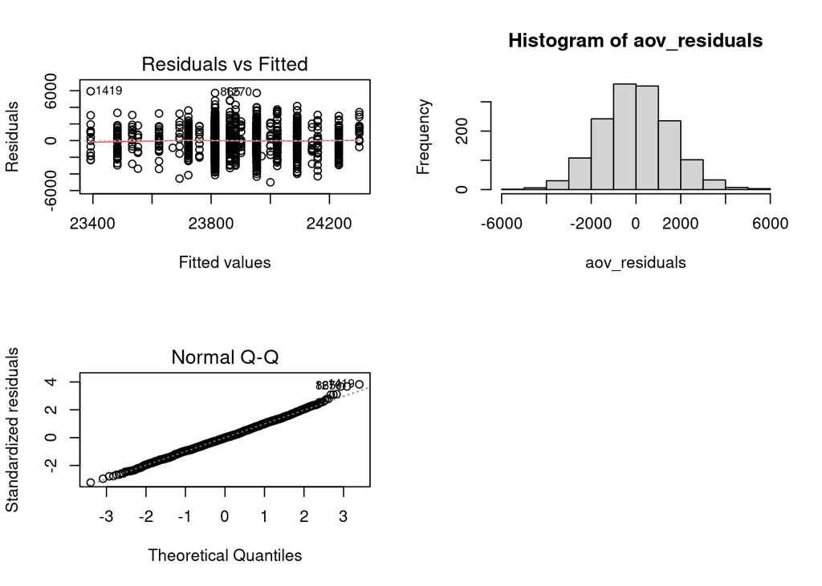

```r
data4$Rating_Mortality_Numbered = ifelse(data4$Rating.Mortality == "Above", 1, ifelse(data1$Release.Console == "Same", 2, 3))


m6=lm(`Procedure.Heart Attack.Cost`~Facility.Type+Rating_Mortality_Numbered+Rating_Safety_Numbered+Rating_Effectiveness_Numbered,data=data4)

almost_sas(m6)

data4$Procedure_Heart_Attack_Cost_Cat <- ifelse(data4$`Procedure.Heart Attack.Cost` < 22894, 0, 1)
#count(data4$Procedure_Heart_Attack_Cost_Cat)

model7=glm(Procedure_Heart_Attack_Cost_Cat~Facility.Type+Rating_Mortality_Numbered+Rating_Safety_Numbered+Rating_Effectiveness_Numbered,data=data4, family="binomial")
summary(model7)
```

**Resulting model.**

```r
extract_eq(model7, use_coefs = TRUE)
```

$$\log\left[ \frac { \widehat{P( \operatorname{Procedure\_Heart\_Attack\_Cost\_Cat} = \operatorname{1} )} }{ 1 - \widehat{P( \operatorname{Procedure\_Heart\_Attack\_Cost\_Cat} = \operatorname{1} )} } \right] = 0.72 - 0.06(\operatorname{Facility.Type}_{\operatorname{Church}}) - 0.25(\operatorname{Facility.Type}_{\operatorname{Government}}) - 0.04(\operatorname{Rating\_Mortality\_Numbered}) + 0.05(\operatorname{Rating\_Safety\_Numbered}) + 0.21(\operatorname{Rating\_Effectiveness\_Numbered})$$

**Significant predictors of heart attack procedure cost. Test at the** $\alpha=0.05$ level.

```r
fullFacility_Type=glm(Procedure_Heart_Attack_Cost_Cat~Facility.Type+Rating_Mortality_Numbered+Rating_Safety_Numbered+Rating_Effectiveness_Numbered,data=data4, family="binomial")
reducedFacility_Type=glm(Procedure_Heart_Attack_Cost_Cat~Rating_Mortality_Numbered+Rating_Safety_Numbered+Rating_Effectiveness_Numbered, data=data4, family="binomial")
anova(reducedFacility_Type, fullFacility_Type, test = "Chisq" )
```

```
Analysis of Deviance Table

Model 1: Procedure_Heart_Attack_Cost_Cat ~ Rating_Mortality_Numbered +
    Rating_Safety_Numbered + Rating_Effectiveness_Numbered
Model 2: Procedure_Heart_Attack_Cost_Cat ~ Facility.Type + Rating_Mortality_Numbered +
    Rating_Safety_Numbered + Rating_Effectiveness_Numbered
  Resid. Df Resid. Dev Df Deviance Pr(>Chi)
1      1478     1706.5
2      1476     1704.0  2   2.5343   0.2816
```

```r
fullRating_Mortality=glm(Procedure_Heart_Attack_Cost_Cat~Facility.Type+Rating_Mortality_Numbered+Rating_Safety_Numbered+Rating_Effectiveness_Numbered, data=data4, family="binomial")
reducedRating_Mortality=glm(Procedure_Heart_Attack_Cost_Cat~Facility.Type+Rating_Safety_Numbered+Rating_Effectiveness_Numbered, data=data4, family="binomial")
anova(reducedRating_Mortality, fullRating_Mortality, test = "Chisq" )
```

```
Analysis of Deviance Table

Model 1: Procedure_Heart_Attack_Cost_Cat ~ Facility.Type + Rating_Safety_Numbered +
    Rating_Effectiveness_Numbered
Model 2: Procedure_Heart_Attack_Cost_Cat ~ Facility.Type + Rating_Mortality_Numbered +
    Rating_Safety_Numbered + Rating_Effectiveness_Numbered
  Resid. Df Resid. Dev Df Deviance Pr(>Chi)
1      1477     1704.3
2      1476     1704.0  1  0.27253   0.6016
```

```r
fullRating_Safety=glm(Procedure_Heart_Attack_Cost_Cat~Facility.Type+Rating_Mortality_Numbered+Rating_Safety_Numbered+Rating_Effectiveness_Numbered, data=data4, family="binomial")
reducedRating_Safety=glm(Procedure_Heart_Attack_Cost_Cat~Facility.Type+Rating_Mortality_Numbered+Rating_Effectiveness_Numbered, data=data4, family="binomial")
anova(reducedRating_Safety, fullRating_Safety, test = "Chisq")
```

```
Analysis of Deviance Table

Model 1: Procedure_Heart_Attack_Cost_Cat ~ Facility.Type + Rating_Mortality_Numbered +
    Rating_Effectiveness_Numbered
Model 2: Procedure_Heart_Attack_Cost_Cat ~ Facility.Type + Rating_Mortality_Numbered +
    Rating_Safety_Numbered + Rating_Effectiveness_Numbered
  Resid. Df Resid. Dev Df Deviance Pr(>Chi)
1      1477     1704.7
2      1476     1704.0  1  0.70718   0.4004
```

```r
fullRating_Effectiveness=glm(Procedure_Heart_Attack_Cost_Cat~Facility.Type+Rating_Mortality_Numbered+Rating_Safety_Numbered+Rating_Effectiveness_Numbered, data=data4, family="binomial")
reducedRating_Effectiveness=glm(Procedure_Heart_Attack_Cost_Cat~Facility.Type+Rating_Mortality_Numbered+Rating_Safety_Numbered, data=data4, family="binomial")
anova(reducedRating_Effectiveness, fullRating_Effectiveness, test = "Chisq" )
```

```
Analysis of Deviance Table

Model 1: Procedure_Heart_Attack_Cost_Cat ~ Facility.Type + Rating_Mortality_Numbered +
    Rating_Safety_Numbered
Model 2: Procedure_Heart_Attack_Cost_Cat ~ Facility.Type + Rating_Mortality_Numbered +
    Rating_Safety_Numbered + Rating_Effectiveness_Numbered
  Resid. Df Resid. Dev Df Deviance Pr(>Chi)
1      1477     1708.6
2      1476     1704.0  1   4.5719   0.0325 *
---
Signif. codes:  0 '***' 0.001 '**' 0.01 '*' 0.05 '.' 0.1 ' ' 1
```

```r
coeftest(model7)
```

```
z test of coefficients:

                               Estimate Std. Error z value Pr(>|z|)
(Intercept)                    0.717637   0.356486  2.0131  0.04411 *
Facility.TypeChurch           -0.057356   0.172039 -0.3334  0.73884
Facility.TypeGovernment       -0.251987   0.156830 -1.6068  0.10811
Rating_Mortality_Numbered     -0.040405   0.077721 -0.5199  0.60315
Rating_Safety_Numbered         0.051098   0.060882  0.8393  0.40131
Rating_Effectiveness_Numbered  0.206472   0.094783  2.1784  0.02938 *
---
Signif. codes:  0 '***' 0.001 '**' 0.01 '*' 0.05 '.' 0.1 ' ' 1
```

I calculated p-value for all the predictors. Except for Rating_Effectiveness_Numbered, they were all greater than alpha=0.05. Thus, I concluded that they were not significant predictors of Procedure_Heart_Attack_Cost_Cat. On the other hand, Rating_Effectiveness_Numbered, I calculated p-value=0.0325, which is less than alpha=0.05.Thus, I concluded that it is a significant predictor of Procedure_Heart_Attack_Cost_Cat.

**Now I am analyzing only hospitals with overall ratings (*Overall.Rating*).**

```r
#count(data4$Rating.Overall)
data4 <- data4 %>% filter(data4$Rating.Overall > 0)
#count(data4$Rating.Overall)
class(data4$Rating.Overall)
```

```
[1] "numeric"
```

**I Modeled the updated heart attack procedure cost as a function of the facility type (I used private as the reference group), and the overall rating.**

```
Call:
glm(formula = Procedure_Heart_Attack_Cost_Cat ~ Facility.Type +
    Rating.Overall, family = "binomial", data = data4)

Deviance Residuals:
    Min       1Q   Median       3Q      Max
-1.7560  -1.5045   0.7631   0.7995   0.9533

Coefficients:
                        Estimate Std. Error z value Pr(>|z|)
(Intercept)              1.40922    0.17982   7.837 4.62e-15 ***
Facility.TypeChurch     -0.04363    0.17182  -0.254   0.7995
Facility.TypeGovernment -0.31530    0.15724  -2.005   0.0449 *
Rating.Overall          -0.10818    0.05323  -2.032   0.0421 *
---
Signif. codes:  0 '***' 0.001 '**' 0.01 '*' 0.05 '.' 0.1 ' ' 1

(Dispersion parameter for binomial family taken to be 1)

    Null deviance: 1712.4  on 1481  degrees of freedom
Residual deviance: 1705.2  on 1478  degrees of freedom
AIC: 1713.2

Number of Fisher Scoring iterations: 4
```

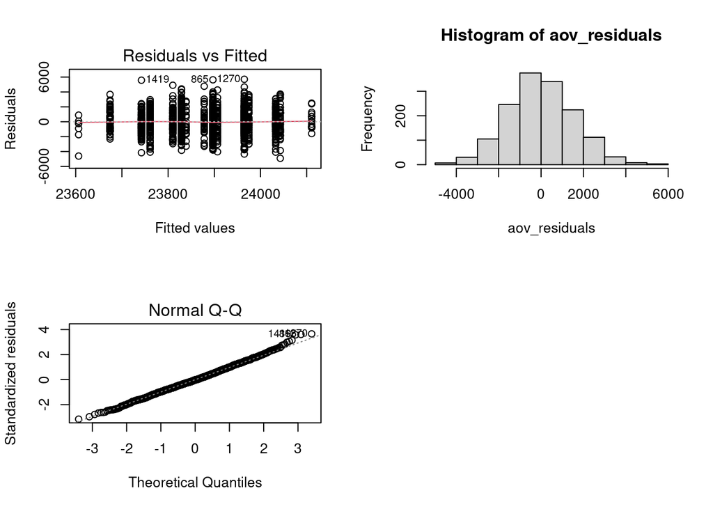

```r
model8=lm(`Procedure.Heart Attack.Cost`~Facility.Type+Rating.Overall,data=data4)
almost_sas(model8)

m8=glm(Procedure_Heart_Attack_Cost_Cat~Facility.Type+Rating.Overall,data=data4, family = "binomial")
summary(m8)
```

**Resulting model.**

```r
extract_eq(m8, use_coefs = TRUE)
```

$$\log\left[ \frac { \widehat{P( \operatorname{Procedure\_Heart\_Attack\_Cost\_Cat} = \operatorname{1} )} }{ 1 - \widehat{P( \operatorname{Procedure\_Heart\_Attack\_Cost\_Cat} = \operatorname{1} )} } \right] = 1.41 - 0.04(\operatorname{Facility.Type}_{\operatorname{Church}}) - 0.32(\operatorname{Facility.Type}_{\operatorname{Government}}) - 0.11(\operatorname{Rating.Overall})$$

**Significant predictors of heart attack procedure cost. Test at the** $\alpha=0.05$ level.

```r
fullFacType=glm(Procedure_Heart_Attack_Cost_Cat~Facility.Type+Rating.Overall,data=data4, family = "binomial")
reducedFacType=glm(Procedure_Heart_Attack_Cost_Cat~Rating.Overall,data=data4, family = "binomial")
anova(reducedFacType, fullFacType, test="Chisq")
```

```
Analysis of Deviance Table

Model 1: Procedure_Heart_Attack_Cost_Cat ~ Rating.Overall
Model 2: Procedure_Heart_Attack_Cost_Cat ~ Facility.Type + Rating.Overall
  Resid. Df Resid. Dev Df Deviance Pr(>Chi)
1      1480     1709.1
2      1478     1705.2  2   3.9416   0.1393
```

```r
fullRatOverall=glm(Procedure_Heart_Attack_Cost_Cat~Facility.Type+Rating.Overall,data=data4, family = "binomial")
reducedRatOverall=glm(Procedure_Heart_Attack_Cost_Cat~Facility.Type,data=data4, family = "binomial")
anova(reducedRatOverall, fullRatOverall, test="Chisq")
```

```
Analysis of Deviance Table

Model 1: Procedure_Heart_Attack_Cost_Cat ~ Facility.Type
Model 2: Procedure_Heart_Attack_Cost_Cat ~ Facility.Type + Rating.Overall
  Resid. Df Resid. Dev Df Deviance Pr(>Chi)
1      1479     1709.3
2      1478     1705.2  1   4.1473   0.0417 *
---
Signif. codes:  0 '***' 0.001 '**' 0.01 '*' 0.05 '.' 0.1 ' ' 1
```

```r
coeftest(m8)
```

```
z test of coefficients:

                         Estimate Std. Error z value  Pr(>|z|)
(Intercept)              1.409223   0.179817  7.8370 4.615e-15 ***
Facility.TypeChurch     -0.043633   0.171824 -0.2539   0.79954
Facility.TypeGovernment -0.315297   0.157238 -2.0052   0.04494 *
Rating.Overall          -0.108175   0.053226 -2.0324   0.04212 *
---
Signif. codes:  0 '***' 0.001 '**' 0.01 '*' 0.05 '.' 0.1 ' ' 1
```

For Facility.Type I calculated p-value= 0.1393, which is greater than alpha=0.05. Thus I concluded that it is not a significant predictor of Procedure_Heart_Attack_Cost_Cat.

For Rating.Overall I calculated p-value=0.0417, which is less than alpha=0.05. Thus I concluded that it is a significant predictor of Procedure_Heart_Attack_Cost_Cat.

**I used 10-fold cross validation to determine if the better model.”**

```r
set.seed(90100)
cv_errormodel7k10 <- cv.glm(data4, model7, K=10)
cv_errormodel7k10$delta
```

```
[1] 0.1951700 0.1950764
```

```r
set.seed(90100)
cv_errorm8k10 <- cv.glm(data4, m8, K=10)
cv_errorm8k10$delta
```

```
[1] 0.1949602 0.1948881
```

I calculated the CV(k=10) of model7 and m8 (model7=0.1951700 0.1950764; m8=0.1949602 0.1948881). In this case model7 CV(k=10) > m8 CV(k=10). Thus, I concluded that m8 fits better than model7.

**Summary relaying the results of the model and interpretations of the slopes!**

```r
c4=coefficients(m8)
c4
```

```
            (Intercept)     Facility.TypeChurch Facility.TypeGovernment
             1.40922318             -0.04363336             -0.31529735
         Rating.Overall
            -0.10817521
```

```r
ec4=round(exp(coefficients(m8)), 4)
ec4
```

```
            (Intercept)     Facility.TypeChurch Facility.TypeGovernment
                 4.0928                  0.9573                  0.7296
         Rating.Overall
                 0.8975
```

**For the model that fit best, I constructed a data visualization to aid in explaining model results.**

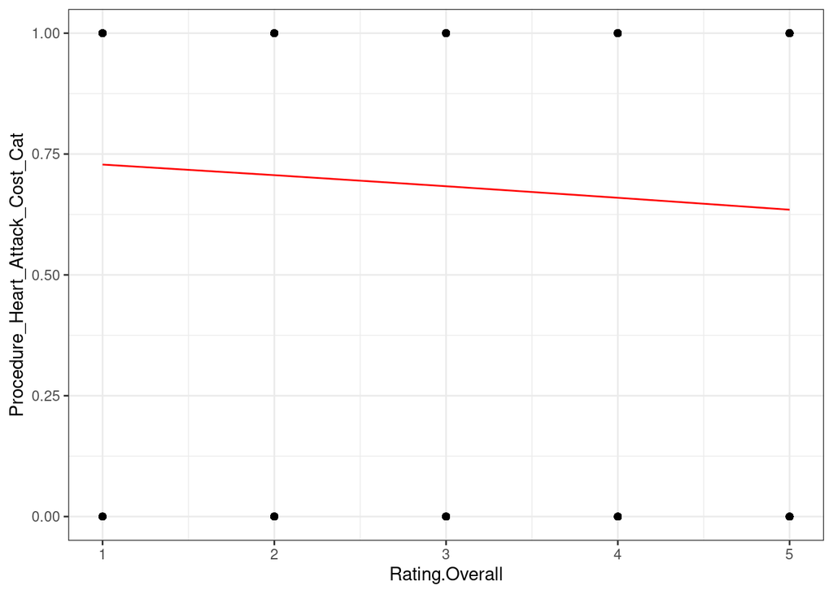

```r
data4=data4%>%mutate(
  pred_R_O=exp(c4[1]+c4[3]+c4[4]*Rating.Overall)/(1+exp(c4[1]+c4[3]+c4[4]*Rating.Overall)),
)

ggplot(data4, aes(x=Rating.Overall, y=Procedure_Heart_Attack_Cost_Cat))+
  geom_point()+
  geom_line(aes(y = pred_R_O), linetype = "solid", color="red")+
 theme_bw()
```

**Billionaire data here: https://corgis-edu.github.io/corgis/csv/billionaires/.**

```r
billionaires <- read_csv("billionaires.csv")
```

**I wanted to figure out how “old” their money is using information from *wealth.how.inherited*. First, I excluded those that inherited money from their spouse. Then, if the money was not inherited, I assigned a 1. If they received the money from a parent, I assigned a 2. From there, I assigned the appropriate generation number. This resulted in a variable that spans 1 to 5.**

```r
data6=billionaires%>%dplyr::select(
  wealth.how.inherited,
 `wealth.worth in billions`,
  demographics.age,
 demographics.gender
)%>%
  na.omit()

#count(data6$wealth.how.inherited)
data6=subset(data6, wealth.how.inherited != "spouse/widow")
data6$wealth.how.inherited <- ifelse(data6$wealth.how.inherited == "not inherited", 1,
                                     ifelse(data6$wealth.how.inherited == "father", 2,
                                            ifelse(data6$wealth.how.inherited == "3rd generation", 3,
                                                   ifelse(data6$wealth.how.inherited == "4th generation", 4, 5))))

#count(data6$wealth.how.inherited)
```

**Second, I converted the wealth (*wealth.worth.in.billions*) into $1 increments. Currently, it’s in billions… if I wanted it in terms of $1, I needed to multiply by 1 billion.**

```r
data6$`wealth.worth in billions` = data6$`wealth.worth in billions` * 1000000000
```

**I modeled the worth of the billionaire (*wealth.worth.in.billions*) as a function of the age of the billionaire (*demographics.age*), biological sex of the billionaire (*demographics.gender*), age of wealth (the variable from problem 4a), and the interaction between the age of the billionaire and the age of their wealth.**

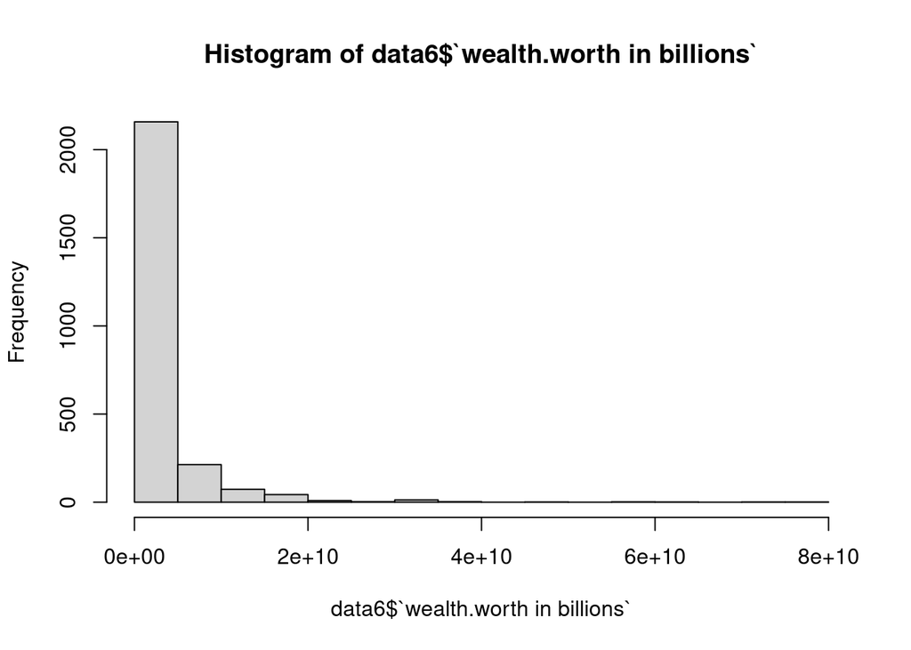

```r
#count(data6$`wealth.worth in billions`)
hist(data6$`wealth.worth in billions`)
```

```r
#count(data6$demographics.gender)
class(data6$demographics.gender)
```

```
[1] "character"
```

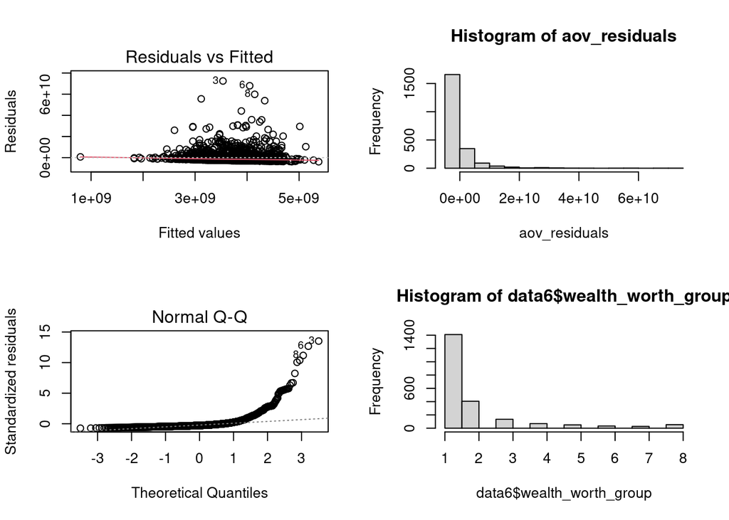

```r
data6$demographics.gender=as.factor(data6$demographics.gender)

#count(data6$demographics.age)
data6 = data6 %>% filter(data6$demographics.age > 0)
#count(data6$demographics.age)


m12=lm(`wealth.worth in billions`~demographics.age+demographics.gender+wealth.how.inherited+demographics.age:wealth.how.inherited, data=data6)
almost_sas(m12)

data6$wealth_worth_group <- ifelse(data6$`wealth.worth in billions` < 2.90e+09, 1,
                  ifelse(data6$`wealth.worth in billions` < 4.90e+09, 2,
                  ifelse(data6$`wealth.worth in billions` < 6.90e+09, 3,
                  ifelse(data6$`wealth.worth in billions` < 9.10e+09, 4,
                  ifelse(data6$`wealth.worth in billions` < 1.15e+10, 5,
                  ifelse(data6$`wealth.worth in billions` < 1.47e+10, 6,
                  ifelse(data6$`wealth.worth in billions` < 1.84e+10, 7, 8)))))))

#count(data6$wealth_worth_group)
hist(data6$wealth_worth_group)
```

```r
mean(data6$wealth_worth_group)
```

```
[1] 1.815307
```

```r
var(data6$wealth_worth_group)
```

```
[1] 2.43309
```

```r
m13 <- glm.nb(wealth_worth_group ~ demographics.age + demographics.gender + wealth.how.inherited + demographics.age:wealth.how.inherited,data = data6)
summary(m13)
```

```
Call:
glm.nb(formula = wealth_worth_group ~ demographics.age + demographics.gender +
    wealth.how.inherited + demographics.age:wealth.how.inherited,
    data = data6, init.theta = 10.71386938, link = log)

Deviance Residuals:
    Min       1Q   Median       3Q      Max
-1.0492  -0.6300  -0.5281   0.1281   3.3430

Coefficients:
                                       Estimate Std. Error z value Pr(>|z|)
(Intercept)                            0.303856   0.180592   1.683   0.0925 .
demographics.age                       0.004649   0.002606   1.784   0.0745 .
demographics.gendermale               -0.040862   0.066511  -0.614   0.5390
wealth.how.inherited                  -0.065899   0.092165  -0.715   0.4746
demographics.age:wealth.how.inherited  0.001447   0.001439   1.006   0.3145
---
Signif. codes:  0 '***' 0.001 '**' 0.01 '*' 0.05 '.' 0.1 ' ' 1

(Dispersion parameter for Negative Binomial(10.7139) family taken to be 1)

    Null deviance: 1676.1  on 2181  degrees of freedom
Residual deviance: 1645.8  on 2177  degrees of freedom
AIC: 7103.3

Number of Fisher Scoring iterations: 1

              Theta:  10.71
          Std. Err.:  1.75

 2 x log-likelihood:  -7091.258
```

The residual graphics revealed the absence of normality in our linear regression model. Thus, I proceeded with a negative binomial regression model. I grouped wealth.worth in billions in eight groups.

**Resulting model.**

```r
extract_eq(m13, use_coefs = TRUE)
```

$$\log ({ \widehat{E( \operatorname{wealth_worth_group} )} }) = 0.3 + 0(\operatorname{demographics.age}) - 0.04(\operatorname{demographics.gender}_{\operatorname{male}}) - 0.07(\operatorname{wealth.how.inherited}) + 0(\operatorname{demographics.age} \times \operatorname{wealth.how.inherited})$$

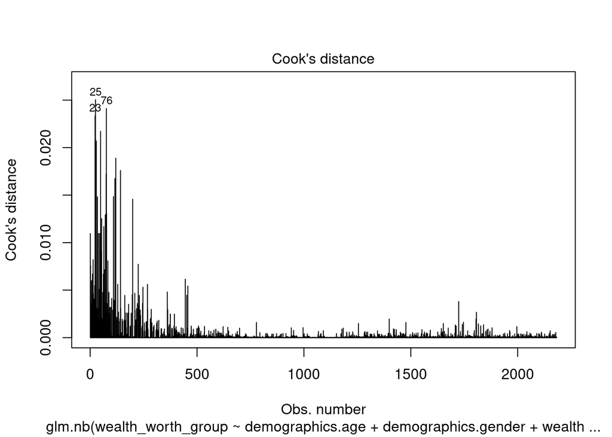

```r
plot(m13, which = 4)
```

```r
m14 <- glm.nb(wealth_worth_group ~ demographics.age + demographics.gender + wealth.how.inherited ,data = data6)
vif(m14)
```

```
    demographics.age  demographics.gender wealth.how.inherited
            1.003858             1.070248             1.068899
```

I checked for outliers. I found three outliers. On the other hand I calculated vif<10. Thus, I concluded that there is not multicolinearity in our model.

**Significant predictors of wealth. Test at the** $\alpha=0.05$ level.

```r
fullage=glm.nb(wealth_worth_group ~ demographics.age + demographics.gender + wealth.how.inherited + demographics.age:wealth.how.inherited,
           data = data6)
reducedage=glm.nb(wealth_worth_group ~  demographics.gender + wealth.how.inherited + demographics.age:wealth.how.inherited,
           data = data6)
anova(reducedage, fullage, test="Chisq")
```

```
Likelihood ratio tests of Negative Binomial Models

Response: wealth_worth_group
                                                                                                  Model
1                    demographics.gender + wealth.how.inherited + demographics.age:wealth.how.inherited
2 demographics.age + demographics.gender + wealth.how.inherited + demographics.age:wealth.how.inherited
     theta Resid. df    2 x log-lik.   Test    df LR stat.    Pr(Chi)
1 10.62655      2178       -7094.415
2 10.71387      2177       -7091.258 1 vs 2     1 3.157383 0.07558424
```

```r
fullgender=glm.nb(wealth_worth_group ~ demographics.age + demographics.gender + wealth.how.inherited + demographics.age:wealth.how.inherited,
           data = data6)
reducedgender=glm.nb(wealth_worth_group ~ demographics.age + wealth.how.inherited + demographics.age:wealth.how.inherited,
           data = data6)
anova(reducedgender, fullgender, test="Chisq")
```

```
Likelihood ratio tests of Negative Binomial Models

Response: wealth_worth_group
                                                                                                  Model
1                       demographics.age + wealth.how.inherited + demographics.age:wealth.how.inherited
2 demographics.age + demographics.gender + wealth.how.inherited + demographics.age:wealth.how.inherited
     theta Resid. df    2 x log-lik.   Test    df  LR stat.   Pr(Chi)
1 10.70475      2178       -7091.632
2 10.71387      2177       -7091.258 1 vs 2     1 0.3747764 0.5404121
```

```r
fullinheritance=glm.nb(wealth_worth_group ~ demographics.age + demographics.gender + wealth.how.inherited + demographics.age:wealth.how.inherited,
           data = data6)
reducedinheritance=glm.nb(wealth_worth_group ~ demographics.age + demographics.age:wealth.how.inherited,
           data = data6)
anova(reducedinheritance, fullinheritance, test="Chisq")
```

```
Likelihood ratio tests of Negative Binomial Models

Response: wealth_worth_group
                                                                                                  Model
1                                              demographics.age + demographics.age:wealth.how.inherited
2 demographics.age + demographics.gender + wealth.how.inherited + demographics.age:wealth.how.inherited
     theta Resid. df    2 x log-lik.   Test    df  LR stat.   Pr(Chi)
1 10.70118      2179       -7092.088
2 10.71387      2177       -7091.258 1 vs 2     2 0.8303466 0.6602258
```

```r
fullINT=glm.nb(wealth_worth_group ~ demographics.age + demographics.gender + wealth.how.inherited + demographics.age:wealth.how.inherited,
           data = data6)
reducedINT=glm.nb(wealth_worth_group ~ demographics.age + demographics.gender + wealth.how.inherited + demographics.age:wealth.how.inherited,
           data = data6)
anova(reducedINT, fullINT, test="Chisq")
```

```
Likelihood ratio tests of Negative Binomial Models

Response: wealth_worth_group
                                                                                                  Model
1 demographics.age + demographics.gender + wealth.how.inherited + demographics.age:wealth.how.inherited
2 demographics.age + demographics.gender + wealth.how.inherited + demographics.age:wealth.how.inherited
     theta Resid. df    2 x log-lik.   Test    df LR stat. Pr(Chi)
1 10.71387      2177       -7091.258
2 10.71387      2177       -7091.258 1 vs 2     0        0       1
```

```r
coeftest(m13)
```

```
z test of coefficients:

                                        Estimate Std. Error z value Pr(>|z|)
(Intercept)                            0.3038561  0.1805917  1.6826  0.09246 .
demographics.age                       0.0046491  0.0026065  1.7837  0.07448 .
demographics.gendermale               -0.0408621  0.0665107 -0.6144  0.53897
wealth.how.inherited                  -0.0658990  0.0921652 -0.7150  0.47460
demographics.age:wealth.how.inherited  0.0014472  0.0014389  1.0058  0.31450
---
Signif. codes:  0 '***' 0.001 '**' 0.01 '*' 0.05 '.' 0.1 ' ' 1
```

I calculated p-value for all the predictors. They were all greater than alpha=0.05. Thus, I concluded that none of the predictors were significant predictors of wealth_worth_group.

**I wrote a brief summary paragraph relaying the results of the model; I included proper interpretations of the slopes.**

```r
c5=coefficients(m13)
c5
```

```
                          (Intercept)                      demographics.age
                          0.303856092                           0.004649078
              demographics.gendermale                  wealth.how.inherited
                         -0.040862103                          -0.065898971
demographics.age:wealth.how.inherited
                          0.001447230
```

```r
ec5=round(exp(coefficients(m13)), 4)
ec5
```

```
                          (Intercept)                      demographics.age
                               1.3551                                1.0047
              demographics.gendermale                  wealth.how.inherited
                               0.9600                                0.9362
demographics.age:wealth.how.inherited
                               1.0014
```

```r
data6=data6%>%mutate(
  pred_1 = exp(c5[1]+c5[2]*demographics.age +c5[3]*1+c5[4]*mean(data6$wealth.how.inherited))
)
```

**I constructed a data visualization to aid in explaining model results.**

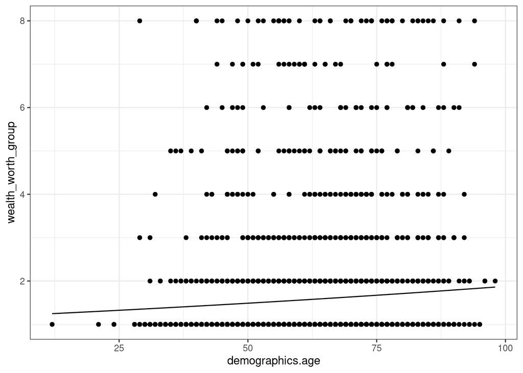

```r
data6 %>% ggplot(aes(x = demographics.age)) +
geom_point(aes(y = wealth_worth_group)) +
geom_line(aes(y = pred_1), color = "black") +
  theme_bw()
```